# Text Mining With R

```r
library(data.table)
library(janeaustenr)
library(tidytext)
library(gutenbergr)
library(stringr)
library(grid)
library(gtable)
library(rlang)
library(scales)
library(ggplot2)
library(ggrepel)
library(RtextminerPkg)
library(RplotterPkg)
```

Author: Rick Dean

Article date: 2021-01-07

Abstract

The following notes/R scripts were inspired from Chapter 1 of [Text Mining With R](https://www.tidytextmining.com/index.html) by Julia Silge and David Robinson

Note: Functions from the `data.table` and `RtextminerPkg` packages are used in performing many of the following data set operations.

# The Tidy Text Format

## Tokenize text into words

### Words from Emily Dickinson text

1. The data:

```r
emily_vec <- c("Because I could not stop for Death",
          "He kindly stopped for me",
          "The Carriage held but just Ourselves",
          "and Immortality")
emily_df <- data.frame(
  line = 1:4,
  text = emily_vec
)
print(emily_df)
##   line                                 text
## 1    1   Because I could not stop for Death
## 2    2             He kindly stopped for me
## 3    3 The Carriage held but just Ourselves
## 4    4                      and Immortality
```

2. Using `RtextminerPkg::tokenize_text()`:

```r
emily_words_lst <- RtextminerPkg::tokenize_text(
  x = emily_df,
  type = "word",
  output_col = "word"
)
```

The returned list *emily_words_lst* is a named list with:

1. A `data.table::data.table` named *tokens_dt* with columns for the text’s line number and corresponding tokenized words from *emily_df*:

```r
emily_words_lst$tokens_dt[1:10]
##     line    word
##  1:    1 because
##  2:    1       i
##  3:    1   could
##  4:    1     not
##  5:    1    stop
##  6:    1     for
##  7:    1   death
##  8:    2      he
##  9:    2  kindly
## 10:    2 stopped
```

2. A `data.table::data.table` named *tokens_count* showing the frequency of each word in *emily_df*:

```r
emily_words_lst$tokens_count[1:6]
##       word N
## 1:     for 2
## 2: because 1
## 3:       i 1
## 4:   could 1
## 5:     not 1
## 6:    stop 1
```

### Words from the works of Jane Austen

1. The data:

```r
jane_austen_books_dt <- data.table::setDT(janeaustenr::austen_books())
str(jane_austen_books_dt)
## Classes 'data.table' and 'data.frame':   73422 obs. of  2 variables:
##  $ text: chr  "SENSE AND SENSIBILITY" "" "by Jane Austen" "" ...
##  $ book: Factor w/ 6 levels "Sense & Sensibility",..: 1 1 1 1 1 1 1 1 1 1 ...
##  - attr(*, ".internal.selfref")=<externalptr>
```

Note: *jane_austen_books_dt* is a data.table and data.frame with a column of character vectors *text* where each vector has a length of 1.

2. Add a *linenumber* and *chapter* columns to *jane_austen_books_dt*:

```r
jane_austen_books_dt[, `:=`(linenumber = .I, chapter = cumsum(str_detect(text, regex("^chapter [\\divxlc]", ignore_case = TRUE))))]
str(jane_austen_books_dt)
## Classes 'data.table' and 'data.frame':   73422 obs. of  4 variables:
##  $ text      : chr  "SENSE AND SENSIBILITY" "" "by Jane Austen" "" ...
##  $ book      : Factor w/ 6 levels "Sense & Sensibility",..: 1 1 1 1 1 1 1 1 1 1 ...
##  $ linenumber: int  1 2 3 4 5 6 7 8 9 10 ...
##  $ chapter   : int  0 0 0 0 0 0 0 0 0 1 ...
##  - attr(*, ".internal.selfref")=<externalptr>
```

3. Using `RtextminerPkg::tokenize_text()` to get the words of Jane Austen books:

```r
austen_words_lst <- RtextminerPkg::tokenize_text(
  x = jane_austen_books_dt,
  input_col = "text",
  output_col = "word",
  stopwords = tidytext::stop_words$word,
  strip_punct = TRUE
)
```

4. Show the words from the text:

```r
austen_words_lst$tokens_dt[1:10]
##                    book linenumber chapter        word
##  1: Sense & Sensibility          1       0       sense
##  2: Sense & Sensibility          1       0 sensibility
##  3: Sense & Sensibility          3       0        jane
##  4: Sense & Sensibility          3       0      austen
##  5: Sense & Sensibility          5       0        1811
##  6: Sense & Sensibility         10       1     chapter
##  7: Sense & Sensibility         10       1           1
##  8: Sense & Sensibility         13       1      family
##  9: Sense & Sensibility         13       1    dashwood
## 10: Sense & Sensibility         13       1     settled
```

5. Show the counts of the words across all the Austen books:

```r
austen_words_lst$tokens_count[1:6]
##     word    N
## 1:  miss 1855
## 2:  time 1337
## 3: fanny  862
## 4:  dear  822
## 5:  lady  817
## 6:   sir  806
```

6. Show the word counts in a bar chart:

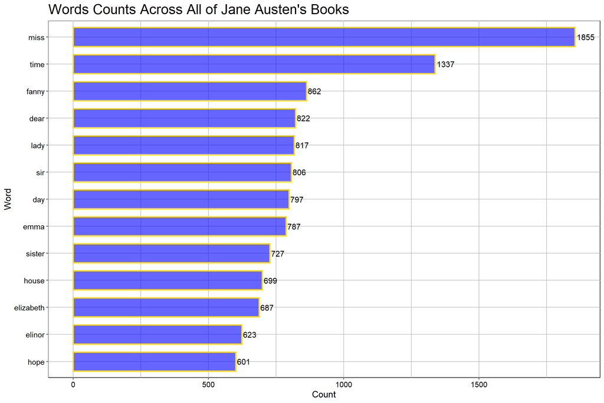

```r
RplotterPkg::create_bar_plot(
  df = austen_words_lst$tokens_count[1:13],
  aes_x = "word",
  aes_y = "N",
  title = "Words Counts Across All of Jane Austen's Books",
  x_title = "Word",
  rot_y_tic_label = T,
  do_coord_flip = T,
  bar_labels = T,
  order_bars = "asc",
  bar_fill = "blue",
  bar_color = "gold",
  bar_alpha = 0.6,
  bar_width = 0.7
)
```

### Words from the works of H.G. Wells using `gutenbergr`package

1. Download the books using `gutenbergr`:

```r
hgwells_books_dt <- data.table::setDT(gutenbergr::gutenberg_download(c(35,36,5230,159)))
str(hgwells_books_dt)
## Classes 'data.table' and 'data.frame':   20347 obs. of  2 variables:
##  $ gutenberg_id: int  35 35 35 35 35 35 35 35 35 35 ...
##  $ text        : chr  "The Time Machine" "" "An Invention" "" ...
##  - attr(*, ".internal.selfref")=<externalptr>
```

2. Using `RtextminerPkg::tokenize_text()` to get the words of H. G. Wells:

```r
hgwells_words_lst <- RtextminerPkg::tokenize_text(
  x = hgwells_books_dt,
  input_col = "text",
  output_col = "word",
  #stopwords = stopwords::stopwords(language = "en"),
  stopwords = tidytext::stop_words$word,
  strip_punct = TRUE
)
```

3. Show the counts of the words across all the H.G. Wells books:

```r
hgwells_words_lst$tokens_count[1:6]
##      word   N
## 1:   time 461
## 2: people 302
## 3:   door 260
## 4:  heard 249
## 5:  black 232
## 6:  stood 229
```

### Words from the works of Bronte sisters using `gutenbergr`package

1. Download the books using `gutenbergr`:

```r
bronte_books_dt <- data.table::setDT(gutenbergr::gutenberg_download(c(1260, 768, 969, 9182, 767)))
str(bronte_books_dt)
## Classes 'data.table' and 'data.frame':   80089 obs. of  2 variables:
##  $ gutenberg_id: int  767 767 767 767 767 767 767 767 767 767 ...
##  $ text        : chr  "Agnes Grey" "A NOVEL," "" "by ACTON BELL." ...
##  - attr(*, ".internal.selfref")=<externalptr>
```

2. Using `RtextminerPkg::tokenize_text()` to get the words of Bronte Sisters:

```r
bronte_words_lst <- RtextminerPkg::tokenize_text(
  x = bronte_books_dt,
  input_col = "text",
  output_col = "word",
  #stopwords = stopwords::stopwords(language = "en"),
  stopwords = tidytext::stop_words$word,
  strip_punct = TRUE
)
```

3. Show the counts of the words across all the Bronte sisters books:

```r
bronte_words_lst$tokens_count[1:6]
##     word    N
## 1:  time 1064
## 2:  miss  854
## 3:   day  826
## 4:  hand  767
## 5:  eyes  713
## 6: don’t  666
```

## Word counts by author/word grouping

1. Create data.tables for each author by selecting the *word* column from the above author’s *tokens_dt* data.table and creating an *author* column:

```r
austen_words_dt <- austen_words_lst$tokens_dt[, .(word = word, author = "JaneAusten")]

hgwells_words_dt <- hgwells_words_lst$tokens_dt[, .(word = word, author = "HGWells")]

bronte_words_dt <- bronte_words_lst$tokens_dt[, .(word = word, author = "BronteSisters")]
```

2. Row bind all of the above word data tables:

```r
words_combined_dt <- data.table::rbindlist(list(
  austen_words_dt,
  hgwells_words_dt,
  bronte_words_dt))
str(words_combined_dt)
## Classes 'data.table' and 'data.frame':   540578 obs. of  2 variables:
##  $ word  : chr  "sense" "sensibility" "jane" "austen" ...
##  $ author: chr  "JaneAusten" "JaneAusten" "JaneAusten" "JaneAusten" ...
##  - attr(*, ".internal.selfref")=<externalptr>
```

3. As a check group *words_combined_dt* by (*author*, *word*) and get the *word* counts:

```r
author_word_counts_dt <- words_combined_dt[, .(.N), by = .(author,word)][order(-N)]
author_word_counts_dt[1:10]
##            author  word    N
##  1:    JaneAusten  miss 1855
##  2:    JaneAusten  time 1337
##  3: BronteSisters  time 1064
##  4:    JaneAusten fanny  862
##  5: BronteSisters  miss  854
##  6: BronteSisters   day  826
##  7:    JaneAusten  dear  822
##  8:    JaneAusten  lady  817
##  9:    JaneAusten   sir  806
## 10:    JaneAusten   day  797
```

Note: Compare these *N*’s with the *N*’s we obtained earlier above.

## Word proportions by author/word grouping

1. Group *author_word_counts_dt* by author and divide *N* by the sum of *N*:

```r
author_word_proportions_dt <- author_word_counts_dt[, .(word, N, prop = N/sum(N)), by = .(author)][order(-prop)]
author_word_proportions_dt[1:10]
##            author   word    N        prop
##  1:    JaneAusten   miss 1855 0.008524464
##  2:       HGWells   time  461 0.006832160
##  3:    JaneAusten   time 1337 0.006144047
##  4:       HGWells people  302 0.004475732
##  5: BronteSisters   time 1064 0.004164481
##  6:    JaneAusten  fanny  862 0.003961233
##  7:       HGWells   door  260 0.003853279
##  8:    JaneAusten   dear  822 0.003777417
##  9:    JaneAusten   lady  817 0.003754440
## 10:    JaneAusten    sir  806 0.003703891
```

## Create a scatter plot of word proportions between authors

1. Turn *author_word_proportions_dt* data table into a “wide” data table where we collect all the *prop* values across the same row based on columns of *author*.

```r
wide_author_dt <- data.table::dcast(author_word_proportions_dt, word ~ author, value.var = "prop")
str(wide_author_dt)
## Classes 'data.table' and 'data.frame':   29957 obs. of  4 variables:
##  $ word         : chr  "1" "10" "10,000" "10,000,000" ...
##  $ BronteSisters: num  7.83e-06 3.91e-06 NA NA NA ...
##  $ HGWells      : num  4.45e-05 NA NA 1.48e-05 1.48e-05 ...
##  $ JaneAusten   : num  3.22e-05 3.22e-05 9.19e-06 NA NA ...
##  - attr(*, ".internal.selfref")=<externalptr>
##  - attr(*, "sorted")= chr "word"
```

2. As a check order the proportions of *JaneAusten* in *wide_author_dt*:

```r
wide_author_dt[order(-JaneAusten)][1:10]
##       word BronteSisters      HGWells  JaneAusten
##  1:   miss  3.342544e-03 1.185624e-04 0.008524464
##  2:   time  4.164481e-03 6.832160e-03 0.006144047
##  3:  fanny  4.305385e-05           NA 0.003961233
##  4:   dear  9.041308e-04 1.185624e-04 0.003777417
##  5:   lady  1.577336e-03 2.667655e-04 0.003754440
##  6:    sir  1.917853e-03 6.669137e-04 0.003703891
##  7:    day  3.232953e-03 2.801037e-03 0.003662532
##  8:   emma            NA           NA 0.003616578
##  9: sister  7.710553e-04 8.892182e-05 0.003340854
## 10:  house  2.277940e-03 2.549092e-03 0.003212183
```

3. Filter *wide_author_dt* to proportions greater than 0.001:

```r
wide_author_filter_dt <- wide_author_dt[JaneAusten > 0.001 & BronteSisters > 0.001 & HGWells > 0.001]
wide_author_filter_dt[1:10]
##      word BronteSisters     HGWells  JaneAusten
##  1: cried   0.001365981 0.001007781 0.001861136
##  2:   day   0.003232953 0.002801037 0.003662532
##  3:  door   0.002313166 0.003853279 0.001089109
##  4:  eyes   0.002790672 0.003112264 0.001387810
##  5: found   0.001585164 0.002964061 0.002155242
##  6:  half   0.002281854 0.001852538 0.002302294
##  7:  hand   0.003002027 0.003230826 0.001121277
##  8:  head   0.001906111 0.002460170 0.001024774
##  9: heard   0.001996133 0.003690256 0.002150646
## 10: house   0.002277940 0.002549092 0.003212183
```

4. Plot the proportions from *wide_author_filter_dt* in scatter plots of *JaneAusten* vs *BronteSisters* and *JaneAusten* vs *HGWells*:

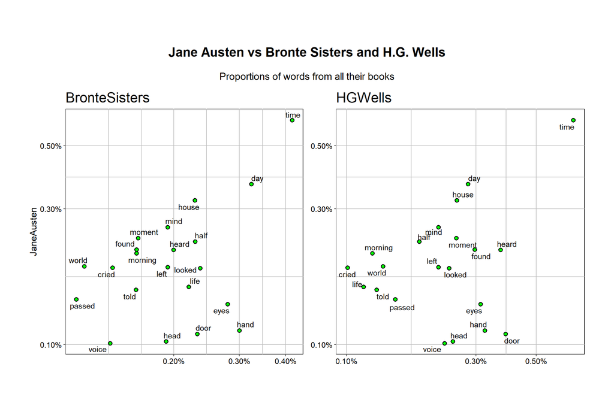

```r
RplotterPkg::multi_scatter_plot(
  df = wide_author_filter_dt,
  title = "Jane Austen vs Bronte Sisters and H.G. Wells",
  subtitle = "Proportions of words from all their books",
  variables = c("BronteSisters", "HGWells"),
  aes_y = "JaneAusten",
  aes_label = "word",
  x_log10 = TRUE,
  y_log10 = TRUE,
  x_labels = scales::percent_format(),
  y_labels = scales::percent_format(),
  rot_y_tic_label = T,
  pts_fill = "green",
  pts_size = 2,
  col_width = 5.5,
  row_height = 5.5
)
```